# Problem Set 6A

**Note**: Due to two non-trivial corrections, we released this (latest) version of the pset on 3/18/2020. Special shoutout to Grace Zhang, who caught the error in 1G and made the original correct plot.

Read [how we grade problem sets](https://www.davidkane.info/post/2019-08-31-problem-sets-and-exams/).

**Objectives for this problem set:**

- Students will demonstrate their understanding of **confidence intervals**
- Students will continue to practice using **list columns and map_* functions**
- Students will practice building a simple **shiny** app

## Sampling and Confidence Intervals

Write a function, `create_deck()` which makes a deck of cards as a tibble with 52 rows and four columns: suit, value, points and name. The cards should be ordered by suit: diamonds, hearts, clubs, spades, and within suit they should go from 2 to Ace. “Name” should paste the value and suit, separated by “of” (ie, “3 of hearts”). J, Q, K, and A should all have a point value of 10.

You don’t need to print anything here, but you should check that your function creates the same deck as ours. The first 13 rows of ours looks like this:

Cards

| Value | Points | Suit | Name |
| --- | --- | --- | --- |
| 2 | 2 | diamonds | 2 of diamonds |
| 3 | 3 | diamonds | 3 of diamonds |
| 4 | 4 | diamonds | 4 of diamonds |
| 5 | 5 | diamonds | 5 of diamonds |
| 6 | 6 | diamonds | 6 of diamonds |
| 7 | 7 | diamonds | 7 of diamonds |
| 8 | 8 | diamonds | 8 of diamonds |
| 9 | 9 | diamonds | 9 of diamonds |
| 10 | 10 | diamonds | 10 of diamonds |
| J | 10 | diamonds | J of diamonds |
| Q | 10 | diamonds | Q of diamonds |
| K | 10 | diamonds | K of diamonds |
| A | 10 | diamonds | A of diamonds |

If your deck is organized like ours, row 50 should be the Queen of spades, worth 10 points.

Now, write a `draw_card()` function. The first step of your function should call create_deck(). Your function should take two parameters (`n` and `report`). `n` will tell you how many cards to draw, and `report` will say which column to return.

Your function should behave like this:

```r
set.seed(1)
draw_card(n = 3, report = "suit")
```

```
## [1] "diamonds" "clubs"    "diamonds"
```

```r
set.seed(1)
draw_card(n = 3, report = "value")
```

```
## [1] "5" "A" "2"
```

```r
set.seed(1)
draw_card(n = 3, report = "points")
```

```
## [1]  5 10  2
```

```r
set.seed(1)
draw_card(n = 3, report = "name")
```

```
## [1] "5 of diamonds" "A of clubs"    "2 of diamonds"
```

Note that we used `set.seed(1)` so that the same three cards were drawn each time, the better to see that an Ace is worth 10 points. You don’t need to print the calls above, but you can use them to check that you’re getting the same values- we’ll be having you set the seed and comparing the output in the next few questions.

## 1A)

[output not shown]

Set the seed to 2. Print a call to your `draw_card` function, where n = 4 and report = “name”.

## 1B)

Set the seed to 3. Make a tibble called “hands” that draws a sample (without replacement) of 5 cards, 100 times. Using map_lgl, create a column of your tibble called “face” which tests whether there are any face cards (J, Q, K) in the hand. Print a `gt` of the first 5 rows of your tibble, which should look like this:

Hands of Five Cards

Checking for Face Values

| Draw | Face Cards? |
| --- | --- |
| 6, K, A, J, 2 | TRUE |
| 5, 6, 9, 8, J | TRUE |
| 2, 10, A, 9, Q | TRUE |
| 3, 4, 6, 7, 6 | FALSE |
| 2, Q, 10, Q, 6 | TRUE |

## 1C)

Set the seed to 4. Draw your own sample of 12 cards, without replacement. Print a gt of your sampled cards here (you can just show the card’s name and point value).

## 1E)

Set the seed to 5. Conduct bootstrapped resampling on your hand of 12 cards. That is, sample from your 12 cards, with replace = TRUE, 1,000 times. Store your resamples in a tibble using a map function, and replicate the plot below, which shows the original sample mean and the mean of the bootstrapped resamples. In one sentence, tell us why the mean of the bootstrapped resamples isn’t exactly the same as the mean of the original sample.

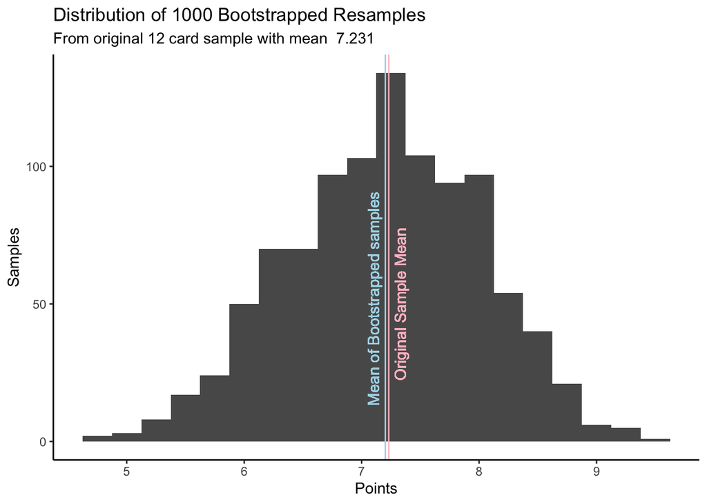

## 1F)

Using your bootstrapped sampling distribution, create “percentile confidence intervals” at the 80%, 90%, 95%, and 99% confidence levels. If you need a refresher, check out *PPBDS* 10.2.1. Make a gt table with two columns; one for the level and one for the interval. Include the sample mean (the (non-bootstrapped) mean points for your sample) as a “source note” at the bottom of your table.

Confidence Intervals for Average Point Value

Bootstrapped Resamples on a 12 Card Hand

| Level | Interval |
| --- | --- |
| 0.80 | (6.1, 8.2) |
| 0.90 | (5.8, 8.5) |
| 0.95 | (5.6, 8.8) |
| 0.99 | (5.2, 9.2) |

Original Sample Mean of 7.23

# 1G)

Now, we’re going to explore how the width of the confidence interval changes 1) as we draw larger and larger samples, and 2) as we change the confidence level. Note that a resample from a sample of 1 card will always get the same card, leading to a confidence interval of 0. So, we’ll set sample sizes to run from 2:52.

Write a function `width_ci <- function(n, level)` that draws a sample hand of `n` cards and creates a confidence interval at the appropriate `confidence_level`. As above, use the percentile method on a bootstrapped sampling distribution with 1000 samples to calculate your confidence interval.

Set the seed to 6. Then, create a tibble which, for three different confidence levels (90%, 95%, 99%) and 51 different sample sizes (2:52) records the width of the bootstrapped confidence interval.

One way to do this is create a column of sample sizes, and then to use three map_dbl() functions to create three columns (width_90, width_95, and width_99) You can then use pivot_longer to create a single `width` column and a `confidence level` column. Your tibble should have 153 rows (51 x 3). (Note: there are a number of ways to create your tibble- as long as you can replicate the plot, any is fine!)

Note that we set the seed because we’re only taking one sample hand *per sample size*, for this exercise. As *PPBDS* points out ``The bootstrap distribution will likely not have the same center as the sampling distribution. In other words, bootstrapping cannot improve the quality of an estimate.’’ If you had not set the seed, you might have drawn a different hand, and your confidence intervals might have been different.

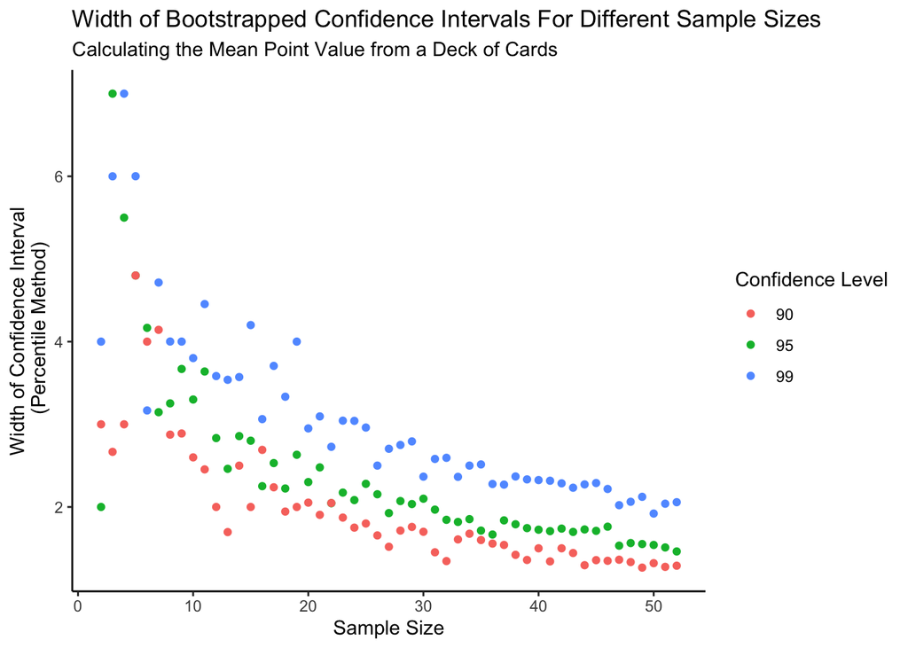

### Question 2: Shiny

We’re going to create a very basic Shiny app; one that just renders your plot from 1G. If this feels too easy- good! That means your TF’s did a good job going over Shiny (or you read the book!). However, there are still important concepts for you to pay attention to in this exercise. In particular, **file organization is going to be extra important from now on.** Start learning best practices for organizing your files for Shiny now, so that you’re not struggling to understand these concepts when you want to upload your awesome final project.

**Instructions**

- Go to file –> new file –> Shiny Web App… You will be prompted to name your web app something. This name will also serve as the name of the directory for the shiny app, where you’ll need to save all the relevant files for your shiny app to run. For this week, we recommend calling this `ps_6_shiny`. Once you’ve titled the app, you’ll notice that the script is called app.R, and that if you go to the `files` pane in Rstudio, you’ll see a new `ps_6_shiny` folder.
- The trickiest bit about Shiny is that only files within the Shiny app directory are bundled up and placed in the cloud for access by the app. Save your plot from 1G to the subdirectory `ps_6_shiny/dist_plot.png` using ggsave. You can check the folder and confirm that your plot is there. Your app.R file, within the Shiny app directory, can now call your file because dist_plot.png is right there, in that directory. It will be bundled up and put in the cloud when you publish your app.
- Shiny apps are extra useful for making *interactive* graphics, but they work fine for pre-rendered images as well. Make a shiny app that takes no input, but simply displays your plot from 1G. You’ll want to use plotOutput in your `ui` section, and `renderImage` in the `server` piece. Note that for `renderImage`, you’ll need to include a list with the filename (this is also a good place to set the width and height of your image). Check out [this page](https://shiny.rstudio.com/articles/images.html) (focus on the “Sending pre-rendered images with renderImage()”) section if you’re stuck.

Once you have your shiny app running, publish it to your account with Shiny.io. Paste the url here. **In other words, the only item in your html for Question 2 is the url.**

### Shiny Tips

- If you like videos, we recommend checking out the [How to Start Shiny video tutorial](https://shiny.rstudio.com/tutorial/).
- If you prefer written guides, check out [Shiny written tutorials](http://shiny.rstudio.com/tutorial/written-tutorial/lesson1/) and [*Mastering Shiny*](https://mastering-shiny.org/) by Hadley Wickham.
- If it were me, I would start with the first three chapters of *Mastering Shiny*, but those students who prefer videos or self-paced tutorials should consider those options.
- Note that the Shiny app directory must be self-contained. If you want to use the pipe or ggplot or any of the Tidyverse functions, you need `library(tidyverse)` at the top of app.R.
- `getwd()` and `setwd()` are your friends for figuring out what is going on in your R Console. Up until now, we have only “stayed” in one directory, the same directory as our project. But, with Shiny, we will need to worry about, at least, the project directory and the Shiny directory, which is within the project directory. The key issue is that you now have files that live into two different directories: the main one and the Shiny app subdirectory. Now, in general, only app.R lives there (and the graphics file you load), but it is an important file. When you are testing it, or running it interactively, you need to be aware that it thinks it is in the Shiny app directory, not the main directory.